# Project Prioritization

## Overview

The *ppr R* package is decision support tool for prioritizing conservation projects. Prioritizations can be developed by maximizing expected feature richness, expected phylogenetic diversity, the number of feature that meet persistence targets, or identifying a set of projects that meet persistence targets for minimal cost. Constraints (e.g. lock in specific actions) and feature weights can also be specified to further customize prioritizations. After defining a project prioritization problem, solutions can be obtained using exact algorithms, heuristic algorithms, or using random processes. In particular, it is recommended to install the [‘Gurobi’ optimizer](https://www.gurobi.com) because it can identify optimal solutions very quickly. Finally, methods are provided for comparing different prioritizations and evaluating their benefits.

## Tutorial

### Introduction

Here we will provide a short tutorial showing how the *ppr R* package can be used to prioritize funding for conservation projects. This package is a general purpose project prioritization decision support tool. It can generate solutions for species-based project prioritization problems (Joseph *et al.* 2009; Bennett *et al.* 2014) and priority threat management problems (Carwardine *et al.* 2018). To develop a project prioritization, this package requires (i) *conservation project* data, (ii) *management action* data, and (iii) *biodiversity feature* data.

Briefly, biodiversity features are the biological entities that we wish would persist into the future (e.g. threatened populations, native species, eco-systems). These *biodiversity features* can (and ideally should) include non-threatened species, but should not include threatening processes that we wish to eradicate (e.g. exotic, invasive, or pest populations). *Management actions* are the specific actions that can performed at a specific location or over a specific area (e.g. planting native species, removing invasive plant species, reintroducing native birds, trapping pest species). Each action should be associated with an estimated cost. To guide the prioritization, the management actions are grouped into *conservation projects* (also termed “strategies”). Typically, management actions are grouped into conservation projects based on spatial (e.g. management actions that pertain the the same area), taxonomic (e.g. management actions that pertain to the same pest or conservation feature), or thematic criteria (e.g. management actions that pertain to pest eradication are grouped into a “pest project” and actions that pertain to habitat restoration are grouped into a “habitat project”). Additionally, some conservation projects can be combinations of other projects (e.g. a “pest and habitat project”). Each conservation project should be associated with (i) a probability of succeeding if it is implemented (also termed “feasibility”), (ii) information about which management actions are associated with it, and (iii) an estimate of how likely each conservation feature affected by the project is to persist into the future if the project is implemented (often derived using expert elicitation). The conservation projects should also include a “baseline project” that represents a “do nothing scenario” which has a 100% chance of succeeding and is associated with an action that costs nothing to implement. For more background information on project prioritization, please refer to Carwardine *et al.* (2018).

To start off, we will set the seed for the random number generator to ensure you get the same results as shown here, load the *ppr R* package, and load the *ggplot2* package to help with data visualizations.

```r
set.seed(500)
library(ppr)
library(ggplot2)
```

### Data simulation

Now we will simulate a dataset to practice developing project prioritizations. Specifically, we will simulate a dataset for a priority threat management exercise that contains 50 features, 100 projects, and 150 actions.

```r
# simulate data
sim_data <- simulate_ptm_data(number_projects = 100, number_actions = 150,
                              number_features = 50)

# extract project, action, feature data
projects <- sim_data$projects
actions <- sim_data$actions
features <- sim_data$features

# print data
print(projects)
```

```
# # A tibble: 101 x 203
#    name  success    F1   F10   F11   F12   F13   F14   F15   F16   F17
#    <chr>   <dbl> <dbl> <dbl> <dbl> <dbl> <dbl> <dbl> <dbl> <dbl> <dbl>
#  1 proj<80>   0.765 0.798 0.784 0.799 0.583 0.519 0.516 0.819 0.643 0.707
#  2 proj<80>   0.899 0.791 0.738 0.518 0.650 0.654 0.856 0.841 0.623 0.614
#  3 proj<80>   0.818 0.681 0.545 0.652 0.846 0.781 0.696 0.850 0.622 0.734
#  4 proj<80>   0.718 0.858 0.595 0.695 0.825 0.720 0.735 0.662 0.747 0.679
#  5 proj<80>   0.704 0.727 0.535 0.720 0.821 0.884 0.607 0.882 0.826 0.633
#  6 proj<80>   0.860 0.581 0.672 0.818 0.629 0.803 0.546 0.555 0.727 0.827
#  7 proj<80>   0.871 0.524 0.529 0.558 0.581 0.680 0.888 0.847 0.780 0.565
#  8 proj<80>   0.939 0.577 0.802 0.799 0.864 0.676 0.823 0.574 0.532 0.589
#  9 proj<80>   0.893 0.803 0.503 0.827 0.587 0.855 0.880 0.830 0.506 0.613
# 10 proj<80>   0.904 0.634 0.820 0.527 0.766 0.622 0.607 0.528 0.695 0.822
# # <80> with 91 more rows, and 192 more variables: F18 <dbl>, F19 <dbl>,
# #   F2 <dbl>, F20 <dbl>, F21 <dbl>, F22 <dbl>, F23 <dbl>, F24 <dbl>,
# #   F25 <dbl>, F26 <dbl>, F27 <dbl>, F28 <dbl>, F29 <dbl>, F3 <dbl>,
# #   F30 <dbl>, F31 <dbl>, F32 <dbl>, F33 <dbl>, F34 <dbl>, F35 <dbl>,
# #   F36 <dbl>, F37 <dbl>, F38 <dbl>, F39 <dbl>, F4 <dbl>, F40 <dbl>,
# #   F41 <dbl>, F42 <dbl>, F43 <dbl>, F44 <dbl>, F45 <dbl>, F46 <dbl>,
# #   F47 <dbl>, F48 <dbl>, F49 <dbl>, F5 <dbl>, F50 <dbl>, F6 <dbl>,
# #   F7 <dbl>, F8 <dbl>, F9 <dbl>, action_1 <lgl>, action_2 <lgl>,
# #   action_3 <lgl>, action_4 <lgl>, action_5 <lgl>, action_6 <lgl>,
# #   action_7 <lgl>, action_8 <lgl>, action_9 <lgl>, action_10 <lgl>,
# #   action_11 <lgl>, action_12 <lgl>, action_13 <lgl>, action_14 <lgl>,
# #   action_15 <lgl>, action_16 <lgl>, action_17 <lgl>, action_18 <lgl>,
# #   action_19 <lgl>, action_20 <lgl>, action_21 <lgl>, action_22 <lgl>,
# #   action_23 <lgl>, action_24 <lgl>, action_25 <lgl>, action_26 <lgl>,
# #   action_27 <lgl>, action_28 <lgl>, action_29 <lgl>, action_30 <lgl>,
# #   action_31 <lgl>, action_32 <lgl>, action_33 <lgl>, action_34 <lgl>,
# #   action_35 <lgl>, action_36 <lgl>, action_37 <lgl>, action_38 <lgl>,
# #   action_39 <lgl>, action_40 <lgl>, action_41 <lgl>, action_42 <lgl>,
# #   action_43 <lgl>, action_44 <lgl>, action_45 <lgl>, action_46 <lgl>,
# #   action_47 <lgl>, action_48 <lgl>, action_49 <lgl>, action_50 <lgl>,
# #   action_51 <lgl>, action_52 <lgl>, action_53 <lgl>, action_54 <lgl>,
# #   action_55 <lgl>, action_56 <lgl>, action_57 <lgl>, action_58 <lgl>,
# #   action_59 <lgl>, <80>
```

```r
print(actions)
```

```
# # A tibble: 151 x 4
#    name       cost locked_in locked_out
#    <chr>     <dbl> <lgl>     <lgl>
#  1 action_1  105.  FALSE     FALSE
#  2 action_2  110.  FALSE     FALSE
#  3 action_3  104.  FALSE     FALSE
#  4 action_4  100.  FALSE     FALSE
#  5 action_5  105.  FALSE     FALSE
#  6 action_6   97.1 FALSE     FALSE
#  7 action_7  104.  FALSE     FALSE
#  8 action_8  103.  FALSE     FALSE
#  9 action_9  100.  FALSE     FALSE
# 10 action_10 101.  FALSE     FALSE
# # <80> with 141 more rows
```

```r
print(features)
```

```
# # A tibble: 50 x 2
#    name     weight
#    <chr>     <dbl>
#  1 F1    0.156
#  2 F2    0.0106
#  3 F3    0.0106
#  4 F4    0.0990
#  5 F5    0.0143
#  6 F6    0.0143
#  7 F7    0.0000913
#  8 F8    0.0000913
#  9 F9    0.00662
# 10 F10   0.00214
# # <80> with 40 more rows
```

### Prioritizations with exact algorithms

Let’s assume that we want to maximize the overall persistence of the conservation features and that we can only spend $3’000 funding management actions. We will also assume that our decisions involve either funding management actions or not (in other words, our decisions are binary). For the moment, let’s assume that we value the persistence of each feature equally. Given this information, we can a project prioritization problem object that matches our specifications.

```r
# build problem
p1 <- problem(projects = projects, actions = actions, features = features,
              "name", "success", "name", "cost", "name") %>%
      add_max_richness_objective(budget = 3000) %>%
      add_binary_decisions()

# print problem
print(p1)
```

```
# Project Prioritization Problem
#   actions          action_1, action_2, action_3, ... (151 actions)
#   projects         project_1, project_2, project_3, ... (101 projects)
#   features         F1, F2, F3, ... (50 features)
#   action costs:    min: 0, max: 111.90657
#   project success: min: 0.70358, max: 1
#   objective:       Maximum richness objective [budget (3000)]
#   targets:         none
#   weights:         default
#   decisions        Binary decision
#   constraints:     <none>
#   solver:          default
```

After building the problem, we can solve it. Although backwards heuristic algorithms have conventionally been used to solve project prioritization problems (e.g. Joseph *et al.* 2009; Bennett *et al.* 2014; Gerber *et al.* 2018), here we will use exact algorithms to develop a prioritization. Exact algorithms are superior to heuristic algorithms because they can provide guarantees on solution quality (Underhill 1994; Rodrigues & Gaston 2002). In other words, if you specify that you want an optimal solution when using exact algorithms, then you are guaranteed to get an optimal solution. Heuristic algorithms—and even more advanced meta-heuristic algorithms such as simulated annealing (Kirkpatrick *et al.* 1983)—provide no such guarantees and can deliver remarkably poor solutions (e.g. Beyer *et al.* 2016). Later on we will try solving problems with heuristic algorithms, but for the moment we will use exact algorithms. Since we haven’t explicitly stated which solver we would like to use, the *ppr R* package will identify the best exact algorithm solver currently installed on your system. This is typically the *Rsymphony R* package unless you have installed the [*gurobi R* package](http://www.gurobi.com/documentation/8.1/quickstart_mac/r_installing_the_r_package.html) and the [Gurobi optimization suite](http://www.gurobi.com/).

```r
# solve problem
s1 <- solve(p1)
```

```
# Optimize a model with 12280 rows, 5352 columns and 34658 nonzeros
# Variable types: 0 continuous, 5302 integer (5302 binary)
# Semi-Variable types: 50 continuous, 0 integer
# Coefficient statistics:
#   Matrix range     [2e-02, 1e+02]
#   Objective range  [1e+00, 1e+00]
#   Bounds range     [1e+00, 1e+00]
#   RHS range        [1e+00, 3e+03]
# Presolve removed 10660 rows and 3978 columns
# Presolve time: 0.79s
# Presolved: 1620 rows, 1374 columns, 5554 nonzeros
# Variable types: 50 continuous, 1324 integer (1324 binary)
# Found heuristic solution: objective 9.9339818
# Found heuristic solution: objective 27.5144813
# Presolved: 1620 rows, 1374 columns, 5554 nonzeros
#
#
# Root relaxation: objective 3.833794e+01, 1320 iterations, 0.05 seconds
#
#     Nodes    |    Current Node    |     Objective Bounds      |     Work
#  Expl Unexpl |  Obj  Depth IntInf | Incumbent    BestBd   Gap | It/Node Time
#
#      0     0   38.33794    0  215   27.51448   38.33794  39.3%     -    0s
# H    0     0                      34.0642488   38.33794  12.5%     -    0s
# H    0     0                      37.7972949   38.33794  1.43%     -    0s
# H    0     0                      38.1394579   38.33794  0.52%     -    0s
#      0     0   38.18425    0  218   38.13946   38.18425  0.12%     -    0s
#
# Explored 1 nodes (1411 simplex iterations) in 0.95 seconds
# Thread count was 1 (of 4 available processors)
#
# Solution count 1: 38.1395
#
# Optimal solution found (tolerance 0.00e+00)
# Best objective 3.813945793887e+01, best bound 3.813945793887e+01, gap 0.0000%
```

```r
# print solution
print(s1)
```

```
# # A tibble: 1 x 205
#   solution status   obj  cost action_1 action_2 action_3 action_4 action_5
#      <int> <chr>  <dbl> <dbl>    <dbl>    <dbl>    <dbl>    <dbl>    <dbl>
# 1        1 OPTIM<80>  38.1 2893.        0        0        0        0        0
# # <80> with 196 more variables: action_6 <dbl>, action_7 <dbl>,
# #   action_8 <dbl>, action_9 <dbl>, action_10 <dbl>, action_11 <dbl>,
# #   action_12 <dbl>, action_13 <dbl>, action_14 <dbl>, action_15 <dbl>,
# #   action_16 <dbl>, action_17 <dbl>, action_18 <dbl>, action_19 <dbl>,
# #   action_20 <dbl>, action_21 <dbl>, action_22 <dbl>, action_23 <dbl>,
# #   action_24 <dbl>, action_25 <dbl>, action_26 <dbl>, action_27 <dbl>,
# #   action_28 <dbl>, action_29 <dbl>, action_30 <dbl>, action_31 <dbl>,
# #   action_32 <dbl>, action_33 <dbl>, action_34 <dbl>, action_35 <dbl>,
# #   action_36 <dbl>, action_37 <dbl>, action_38 <dbl>, action_39 <dbl>,
# #   action_40 <dbl>, action_41 <dbl>, action_42 <dbl>, action_43 <dbl>,
# #   action_44 <dbl>, action_45 <dbl>, action_46 <dbl>, action_47 <dbl>,
# #   action_48 <dbl>, action_49 <dbl>, action_50 <dbl>, action_51 <dbl>,
# #   action_52 <dbl>, action_53 <dbl>, action_54 <dbl>, action_55 <dbl>,
# #   action_56 <dbl>, action_57 <dbl>, action_58 <dbl>, action_59 <dbl>,
# #   action_60 <dbl>, action_61 <dbl>, action_62 <dbl>, action_63 <dbl>,
# #   action_64 <dbl>, action_65 <dbl>, action_66 <dbl>, action_67 <dbl>,
# #   action_68 <dbl>, action_69 <dbl>, action_70 <dbl>, action_71 <dbl>,
# #   action_72 <dbl>, action_73 <dbl>, action_74 <dbl>, action_75 <dbl>,
# #   action_76 <dbl>, action_77 <dbl>, action_78 <dbl>, action_79 <dbl>,
# #   action_80 <dbl>, action_81 <dbl>, action_82 <dbl>, action_83 <dbl>,
# #   action_84 <dbl>, action_85 <dbl>, action_86 <dbl>, action_87 <dbl>,
# #   action_88 <dbl>, action_89 <dbl>, action_90 <dbl>, action_91 <dbl>,
# #   action_92 <dbl>, action_93 <dbl>, action_94 <dbl>, action_95 <dbl>,
# #   action_96 <dbl>, action_97 <dbl>, action_98 <dbl>, action_99 <dbl>,
# #   action_100 <dbl>, action_101 <dbl>, action_102 <dbl>,
# #   action_103 <dbl>, action_104 <dbl>, action_105 <dbl>, <80>
```

```r
# calculate number of actions prioritized for funding
sum(as.matrix(s1[, grepl("action", names(s1))]))
```

```
# [1] 29
```

The `s1` table contains the solution and also various statistics associated with the solution. Here, each row corresponds to a different solution. By default only one solution will be returned, and so the table has one row. The `"solution"` column contains an integer identifier for the solution (which may be useful for methods that output multiple solutions), the `"obj"` column contains the objective value (i.e. the expected feature richness in this case), the `"cost"` column stores the cost of the solution, and the `"status"` column contains information from the solver about the solution. Additionally, it contains columns for each action (`"action_1"`, `"action_2"`, `"action_3"`, …, `"baseline_action"`) which indicate if each action was prioritized for funding in the solution. Furthermore, it contains columns for each feature (`"F1`, `"F2"`, `"F3`, …) which indicate the probability that each feature is expected to persist into the future if the solutions were implemented.

Since tabular data can be difficult to understand, let’s create a bar plot to visualize how well this solution would conserve the features. In this plot, each bar corresponds to a different feature, the width of each bar corresponds to its expected probability of persistence, the color of each bar corresponds to the feature’s weight (all bars are the same color here since we didn’t specify any weights). Asterisks denote features that benefit from fully funded projects, and open circles denote features that benefit do not benefit from fully funded projects.

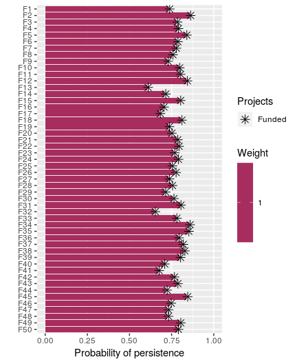

```r
# plot solution
plot(p1, s1)
```

Overall, we can see that most species have a fairly decent chance at persisting into the future (approx. 76%). But when making this prioritization, we assumed that we valued the persistence of each feature equally. It is often important to account for the fact that certain features are valued more highly than other features when making prioritizations (e.g. for cultural or taxonomic reasons). The `features` table that we created earlier contains a `"weight"` column, and features with larger values mean that they are more important. Let’s quickly visualize the feature weight values.

```r
# print features table
print(features)
```

```
# # A tibble: 50 x 2
#    name     weight
#    <chr>     <dbl>
#  1 F1    0.156
#  2 F2    0.0106
#  3 F3    0.0106
#  4 F4    0.0990
#  5 F5    0.0143
#  6 F6    0.0143
#  7 F7    0.0000913
#  8 F8    0.0000913
#  9 F9    0.00662
# 10 F10   0.00214
# # <80> with 40 more rows
```

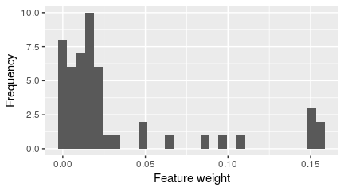

```r
# plot histogram of feature weights
ggplot(data = features, aes(weight)) +
geom_histogram(bins = 30) +
xlab("Feature weight") +
ylab("Frequency")
```

We can see that most features have a low weighting (less than 0.05), but there are a few features with much higher weightings (greater than 0.15). Let’s try adding the feature weights to the problem, and then solve the new problem.

```r
# build on existing problem and add feature weights
p2 <- p1 %>%
      add_feature_weights("weight")

# print problem
print(p2)
```

```
# Project Prioritization Problem
#   actions          action_1, action_2, action_3, ... (151 actions)
#   projects         project_1, project_2, project_3, ... (101 projects)
#   features         F1, F2, F3, ... (50 features)
#   action costs:    min: 0, max: 111.90657
#   project success: min: 0.70358, max: 1
#   objective:       Maximum richness objective [budget (3000)]
#   targets:         none
#   weights:         min: 3e-05, max: 0.156
#   decisions        Binary decision
#   constraints:     <none>
#   solver:          default
```

```r
# solve problem
s2 <- solve(p2)
```

```
# Optimize a model with 12280 rows, 5352 columns and 34658 nonzeros
# Variable types: 0 continuous, 5302 integer (5302 binary)
# Semi-Variable types: 50 continuous, 0 integer
# Coefficient statistics:
#   Matrix range     [2e-02, 1e+02]
#   Objective range  [3e-05, 2e-01]
#   Bounds range     [1e+00, 1e+00]
#   RHS range        [1e+00, 3e+03]
# Presolve removed 10660 rows and 3978 columns
# Presolve time: 1.19s
# Presolved: 1620 rows, 1374 columns, 5554 nonzeros
# Variable types: 50 continuous, 1324 integer (1324 binary)
# Found heuristic solution: objective 0.3216700
# Found heuristic solution: objective 0.9495332
# Presolved: 1620 rows, 1374 columns, 5554 nonzeros
#
#
# Root relaxation: objective 1.277980e+00, 1349 iterations, 0.05 seconds
#
#     Nodes    |    Current Node    |     Objective Bounds      |     Work
#  Expl Unexpl |  Obj  Depth IntInf | Incumbent    BestBd   Gap | It/Node Time
#
#      0     0    1.27798    0  245    0.94953    1.27798  34.6%     -    1s
# H    0     0                       1.1448505    1.27798  11.6%     -    1s
# H    0     0                       1.2118250    1.27798  5.46%     -    1s
# H    0     0                       1.2576825    1.27798  1.61%     -    1s
# H    0     0                       1.2642883    1.27798  1.08%     -    1s
#      0     0    1.27044    0  123    1.26429    1.27044  0.49%     -    1s
# H    0     0                       1.2660350    1.27044  0.35%     -    1s
#      0     0    1.26943    0  120    1.26603    1.26943  0.27%     -    1s
#      0     0    1.26872    0  117    1.26603    1.26872  0.21%     -    1s
#      0     0    1.26716    0   18    1.26603    1.26716  0.09%     -    1s
#      0     0     cutoff    0         1.26603    1.26603  0.00%     -    1s
#
# Cutting planes:
#   Gomory: 2
#   Cover: 1
#   Zero half: 14
#
# Explored 1 nodes (1862 simplex iterations) in 1.49 seconds
# Thread count was 1 (of 4 available processors)
#
# Solution count 1: 1.26603
#
# Optimal solution found (tolerance 0.00e+00)
# Best objective 1.266034979385e+00, best bound 1.266034979385e+00, gap 0.0000%
```

```r
# print solution
print(s2)
```

```
# # A tibble: 1 x 205
#   solution status   obj  cost action_1 action_2 action_3 action_4 action_5
#      <int> <chr>  <dbl> <dbl>    <dbl>    <dbl>    <dbl>    <dbl>    <dbl>
# 1        1 OPTIM<80>  1.27 2990.        0        0        0        0        0
# # <80> with 196 more variables: action_6 <dbl>, action_7 <dbl>,
# #   action_8 <dbl>, action_9 <dbl>, action_10 <dbl>, action_11 <dbl>,
# #   action_12 <dbl>, action_13 <dbl>, action_14 <dbl>, action_15 <dbl>,
# #   action_16 <dbl>, action_17 <dbl>, action_18 <dbl>, action_19 <dbl>,
# #   action_20 <dbl>, action_21 <dbl>, action_22 <dbl>, action_23 <dbl>,
# #   action_24 <dbl>, action_25 <dbl>, action_26 <dbl>, action_27 <dbl>,
# #   action_28 <dbl>, action_29 <dbl>, action_30 <dbl>, action_31 <dbl>,
# #   action_32 <dbl>, action_33 <dbl>, action_34 <dbl>, action_35 <dbl>,
# #   action_36 <dbl>, action_37 <dbl>, action_38 <dbl>, action_39 <dbl>,
# #   action_40 <dbl>, action_41 <dbl>, action_42 <dbl>, action_43 <dbl>,
# #   action_44 <dbl>, action_45 <dbl>, action_46 <dbl>, action_47 <dbl>,
# #   action_48 <dbl>, action_49 <dbl>, action_50 <dbl>, action_51 <dbl>,
# #   action_52 <dbl>, action_53 <dbl>, action_54 <dbl>, action_55 <dbl>,
# #   action_56 <dbl>, action_57 <dbl>, action_58 <dbl>, action_59 <dbl>,
# #   action_60 <dbl>, action_61 <dbl>, action_62 <dbl>, action_63 <dbl>,
# #   action_64 <dbl>, action_65 <dbl>, action_66 <dbl>, action_67 <dbl>,
# #   action_68 <dbl>, action_69 <dbl>, action_70 <dbl>, action_71 <dbl>,
# #   action_72 <dbl>, action_73 <dbl>, action_74 <dbl>, action_75 <dbl>,
# #   action_76 <dbl>, action_77 <dbl>, action_78 <dbl>, action_79 <dbl>,
# #   action_80 <dbl>, action_81 <dbl>, action_82 <dbl>, action_83 <dbl>,
# #   action_84 <dbl>, action_85 <dbl>, action_86 <dbl>, action_87 <dbl>,
# #   action_88 <dbl>, action_89 <dbl>, action_90 <dbl>, action_91 <dbl>,
# #   action_92 <dbl>, action_93 <dbl>, action_94 <dbl>, action_95 <dbl>,
# #   action_96 <dbl>, action_97 <dbl>, action_98 <dbl>, action_99 <dbl>,
# #   action_100 <dbl>, action_101 <dbl>, action_102 <dbl>,
# #   action_103 <dbl>, action_104 <dbl>, action_105 <dbl>, <80>
```

```r
# calculate number of actions prioritized for funding
sum(as.matrix(s2[, grepl("action", names(s2))]))
```

```
# [1] 30
```

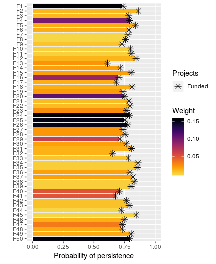

```r
# plot solution
plot(p2, s2)
```

We can also examine how adding feature weights changed our solution. Specifically, we can calculate the number of projects that were given the same status (i.e. zero or one) and the number of projects that changed when adding the weights (e.g. went from zero to one, or vice versa).

```r
# calculate number of actions that were assigned the same status
sum((as.matrix(s1[, grepl("action", names(s1))]) -
     as.matrix(s2[, grepl("action", names(s2))])) == 0)
```

```
# [1] 150
```

```r
# calculate number of actions that were assigned a different status when
# adding the weights
sum((as.matrix(s1[, grepl("action", names(s1))]) -
     as.matrix(s2[, grepl("action", names(s2))])) != 0)
```

```
# [1] 1
```

Earlier, we talked about the *ppr* using the default exact algorithm solver. Although you should have the *Rsymphony* solver automatically installed, we strongly recommend installing the [*gurobi R* package](http://www.gurobi.com/documentation/8.1/quickstart_mac/r_installing_the_r_package.html) and the [Gurobi optimization suite](http://www.gurobi.com/). This is because Gurobi can solve optimization problems much faster than any other software and it can also be used to easily generate multiple solutions. Unfortunately, you will have to install Gurobi manually, but please see `?add_gurobi_solver` for instructions. If you have Gurobi installed, let’s try using the Gurobi solver to generate multiple solutions. Here, we will manually specify the Gurobi solver and request 1’000 solutions (though we will probably obtain less than 1’000 solutions so if we actually wanted 1’000 solutions we would need to specify a much larger number).

```r
# create new problem, with gurobi solver added and request multiple solutions
p3 <- p2 %>%
      add_gurobi_solver(number_solution = 1000)

# solve problem
s3 <- solve(p3)
```

```
# Optimize a model with 12280 rows, 5352 columns and 34658 nonzeros
# Variable types: 0 continuous, 5302 integer (5302 binary)
# Semi-Variable types: 50 continuous, 0 integer
# Coefficient statistics:
#   Matrix range     [2e-02, 1e+02]
#   Objective range  [3e-05, 2e-01]
#   Bounds range     [1e+00, 1e+00]
#   RHS range        [1e+00, 3e+03]
# Presolve removed 10660 rows and 3978 columns
# Presolve time: 0.80s
# Presolved: 1620 rows, 1374 columns, 5554 nonzeros
# Variable types: 50 continuous, 1324 integer (1324 binary)
# Found heuristic solution: objective 0.3216700
# Found heuristic solution: objective 0.9495332
# Found heuristic solution: objective 0.9826677
# Presolved: 1620 rows, 1374 columns, 5554 nonzeros
#
#
# Root relaxation: objective 1.277980e+00, 1349 iterations, 0.04 seconds
#
#     Nodes    |    Current Node    |     Objective Bounds      |     Work
#  Expl Unexpl |  Obj  Depth IntInf | Incumbent    BestBd   Gap | It/Node Time
#
#      0     0    1.27798    0  245    0.98267    1.27798  30.1%     -    0s
# H    0     0                       1.1845676    1.27798  7.89%     -    0s
# H    0     0                       1.2118250    1.27798  5.46%     -    0s
# H    0     0                       1.2576825    1.27798  1.61%     -    0s
# H    0     0                       1.2642883    1.27798  1.08%     -    0s
#      0     0    1.27064    0  256    1.26429    1.27064  0.50%     -    0s
#      0     0    1.27060    0  255    1.26429    1.27060  0.50%     -    1s
#      0     0    1.26929    0  107    1.26429    1.26929  0.40%     -    1s
#      0     0    1.26917    0  108    1.26429    1.26917  0.39%     -    1s
#      0     0    1.26872    0  272    1.26429    1.26872  0.35%     -    1s
#      0     0    1.26867    0  270    1.26429    1.26867  0.35%     -    1s
#      0     0    1.26866    0  273    1.26429    1.26866  0.35%     -    1s
#      0     0    1.26865    0  273    1.26429    1.26865  0.34%     -    1s
#      0     0    1.26865    0  273    1.26429    1.26865  0.34%     -    1s
# H    0     0                       1.2660350    1.26865  0.21%     -    1s
#      0     2    1.26864    0  273    1.26603    1.26864  0.21%     -    1s
# Optimal solution found at node 524 - now completing solution pool...
#   3294  1822    1.26352   78    4    1.26603    1.26603  0.00%   2.8    5s
#  15303  3719          -  176         1.26603    1.26603  0.00%   1.4   16s
#  26656  4256     cutoff   81         1.26603    1.26603  0.00%   1.2   20s
#  40237  2027          -  170         1.26603    1.26603  0.00%   1.0   25s
#  51938   234          -  190         1.26603    1.26603  0.00%   0.9   30s
#
# Cutting planes:
#   Gomory: 5
#   Cover: 10
#   Implied bound: 4
#   Clique: 126
#   MIR: 3
#   StrongCG: 1
#   Flow cover: 8
#   Zero half: 24
#
# Explored 55641 nodes (51798 simplex iterations) in 31.44 seconds
# Thread count was 1 (of 4 available processors)
#
# Solution count 1000: 1.26603 1.26603 1.26603 ... 1.26603
# No other solutions better than 1.26603
#
# Optimal solution found (tolerance 0.00e+00)
# Best objective 1.266034979385e+00, best bound 1.266034979385e+00, gap 0.0000%
```

```r
# print solution
print(s3)
```

```
# # A tibble: 226 x 205
#    solution status   obj  cost action_1 action_2 action_3 action_4 action_5
#       <int> <chr>  <dbl> <dbl>    <dbl>    <dbl>    <dbl>    <dbl>    <dbl>
#  1        1 OPTIM<80>  1.27 2893.        0        0        0        0        0
#  2        2 OPTIM<80>  1.27 2990.        0        0        0        0        0
#  3        3 OPTIM<80>  1.27 2991.        0        0        0        0        0
#  4        4 OPTIM<80>  1.27 2989.        0        0        0        0        0
#  5        5 OPTIM<80>  1.27 2998.        1        0        0        0        0
#  6        6 OPTIM<80>  1.27 2999.        0        0        0        0        0
#  7        7 OPTIM<80>  1.27 2991.        0        0        0        0        0
#  8        8 OPTIM<80>  1.27 2990.        0        0        0        0        0
#  9        9 OPTIM<80>  1.27 2998.        0        0        0        0        0
# 10       10 OPTIM<80>  1.27 2998.        0        0        0        0        0
# # <80> with 216 more rows, and 196 more variables: action_6 <dbl>,
# #   action_7 <dbl>, action_8 <dbl>, action_9 <dbl>, action_10 <dbl>,
# #   action_11 <dbl>, action_12 <dbl>, action_13 <dbl>, action_14 <dbl>,
# #   action_15 <dbl>, action_16 <dbl>, action_17 <dbl>, action_18 <dbl>,
# #   action_19 <dbl>, action_20 <dbl>, action_21 <dbl>, action_22 <dbl>,
# #   action_23 <dbl>, action_24 <dbl>, action_25 <dbl>, action_26 <dbl>,
# #   action_27 <dbl>, action_28 <dbl>, action_29 <dbl>, action_30 <dbl>,
# #   action_31 <dbl>, action_32 <dbl>, action_33 <dbl>, action_34 <dbl>,
# #   action_35 <dbl>, action_36 <dbl>, action_37 <dbl>, action_38 <dbl>,
# #   action_39 <dbl>, action_40 <dbl>, action_41 <dbl>, action_42 <dbl>,
# #   action_43 <dbl>, action_44 <dbl>, action_45 <dbl>, action_46 <dbl>,
# #   action_47 <dbl>, action_48 <dbl>, action_49 <dbl>, action_50 <dbl>,
# #   action_51 <dbl>, action_52 <dbl>, action_53 <dbl>, action_54 <dbl>,
# #   action_55 <dbl>, action_56 <dbl>, action_57 <dbl>, action_58 <dbl>,
# #   action_59 <dbl>, action_60 <dbl>, action_61 <dbl>, action_62 <dbl>,
# #   action_63 <dbl>, action_64 <dbl>, action_65 <dbl>, action_66 <dbl>,
# #   action_67 <dbl>, action_68 <dbl>, action_69 <dbl>, action_70 <dbl>,
# #   action_71 <dbl>, action_72 <dbl>, action_73 <dbl>, action_74 <dbl>,
# #   action_75 <dbl>, action_76 <dbl>, action_77 <dbl>, action_78 <dbl>,
# #   action_79 <dbl>, action_80 <dbl>, action_81 <dbl>, action_82 <dbl>,
# #   action_83 <dbl>, action_84 <dbl>, action_85 <dbl>, action_86 <dbl>,
# #   action_87 <dbl>, action_88 <dbl>, action_89 <dbl>, action_90 <dbl>,
# #   action_91 <dbl>, action_92 <dbl>, action_93 <dbl>, action_94 <dbl>,
# #   action_95 <dbl>, action_96 <dbl>, action_97 <dbl>, action_98 <dbl>,
# #   action_99 <dbl>, action_100 <dbl>, action_101 <dbl>, action_102 <dbl>,
# #   action_103 <dbl>, action_104 <dbl>, action_105 <dbl>, <80>
```

We obtained 226 solutions. Let’s explore briefly them.

```r
# calculate number of optimal solutions
sum(s3$obj == max(s3$obj))
```

```
# [1] 226
```

```r
# plot histogram of objective values
ggplot(data = s3, aes(obj)) +
geom_histogram(bins = 30) +
xlab("Expected richness (objective function)") +
ylab("Frequency")
```

```
# Warning: Computation failed in `stat_bin()`:
# `binwidth` must be positive
```

[figure not shown]

### Assessing action importance

After obtaining a solution (or even multiple solutions) to a project prioritization problem, it is often important to understand which of priority actions are most important. This is because it may not be possible to implement all actions immediately and simultaneously, and since some conservation projects may be less likely to succeed if their management actions are delayed, it may be useful to decision makers with a measure of importance for each action (also termed irreplaceability or vulnerability). For example, if a pest eradication project is delayed and the pest population is given an opportunity to increase, then the success of the pest eradication project may diminish over time. One simple—but often inaccurate—approach for assessing the importance of priority actions (i.e. actions selected for funding in a solution) is calculating the “selection frequency” of the actions. Given multiple near-optimal solutions, this metric involves calculating the average number of times that each priority action is selected (Ball *et al.* 2009). For illustrative purposes, we shall compute the selection frequency of the solutions we obtained previously (i.e. the `s3` object).

```r
# print the solution object to remind ourselves what it looks like
print(s3)
```

```
# # A tibble: 226 x 205
#    solution status   obj  cost action_1 action_2 action_3 action_4 action_5
#       <int> <chr>  <dbl> <dbl>    <dbl>    <dbl>    <dbl>    <dbl>    <dbl>
#  1        1 OPTIM<80>  1.27 2893.        0        0        0        0        0
#  2        2 OPTIM<80>  1.27 2990.        0        0        0        0        0
#  3        3 OPTIM<80>  1.27 2991.        0        0        0        0        0
#  4        4 OPTIM<80>  1.27 2989.        0        0        0        0        0
#  5        5 OPTIM<80>  1.27 2998.        1        0        0        0        0
#  6        6 OPTIM<80>  1.27 2999.        0        0        0        0        0
#  7        7 OPTIM<80>  1.27 2991.        0        0        0        0        0
#  8        8 OPTIM<80>  1.27 2990.        0        0        0        0        0
#  9        9 OPTIM<80>  1.27 2998.        0        0        0        0        0
# 10       10 OPTIM<80>  1.27 2998.        0        0        0        0        0
# # <80> with 216 more rows, and 196 more variables: action_6 <dbl>,
# #   action_7 <dbl>, action_8 <dbl>, action_9 <dbl>, action_10 <dbl>,
# #   action_11 <dbl>, action_12 <dbl>, action_13 <dbl>, action_14 <dbl>,
# #   action_15 <dbl>, action_16 <dbl>, action_17 <dbl>, action_18 <dbl>,
# #   action_19 <dbl>, action_20 <dbl>, action_21 <dbl>, action_22 <dbl>,
# #   action_23 <dbl>, action_24 <dbl>, action_25 <dbl>, action_26 <dbl>,
# #   action_27 <dbl>, action_28 <dbl>, action_29 <dbl>, action_30 <dbl>,
# #   action_31 <dbl>, action_32 <dbl>, action_33 <dbl>, action_34 <dbl>,
# #   action_35 <dbl>, action_36 <dbl>, action_37 <dbl>, action_38 <dbl>,
# #   action_39 <dbl>, action_40 <dbl>, action_41 <dbl>, action_42 <dbl>,
# #   action_43 <dbl>, action_44 <dbl>, action_45 <dbl>, action_46 <dbl>,
# #   action_47 <dbl>, action_48 <dbl>, action_49 <dbl>, action_50 <dbl>,
# #   action_51 <dbl>, action_52 <dbl>, action_53 <dbl>, action_54 <dbl>,
# #   action_55 <dbl>, action_56 <dbl>, action_57 <dbl>, action_58 <dbl>,
# #   action_59 <dbl>, action_60 <dbl>, action_61 <dbl>, action_62 <dbl>,
# #   action_63 <dbl>, action_64 <dbl>, action_65 <dbl>, action_66 <dbl>,
# #   action_67 <dbl>, action_68 <dbl>, action_69 <dbl>, action_70 <dbl>,
# #   action_71 <dbl>, action_72 <dbl>, action_73 <dbl>, action_74 <dbl>,
# #   action_75 <dbl>, action_76 <dbl>, action_77 <dbl>, action_78 <dbl>,
# #   action_79 <dbl>, action_80 <dbl>, action_81 <dbl>, action_82 <dbl>,
# #   action_83 <dbl>, action_84 <dbl>, action_85 <dbl>, action_86 <dbl>,
# #   action_87 <dbl>, action_88 <dbl>, action_89 <dbl>, action_90 <dbl>,
# #   action_91 <dbl>, action_92 <dbl>, action_93 <dbl>, action_94 <dbl>,
# #   action_95 <dbl>, action_96 <dbl>, action_97 <dbl>, action_98 <dbl>,
# #   action_99 <dbl>, action_100 <dbl>, action_101 <dbl>, action_102 <dbl>,
# #   action_103 <dbl>, action_104 <dbl>, action_105 <dbl>, <80>
```

```r
# calculate percentage of times each action was selected for
# funding in the solutions
actions$sel_freq <- apply(as.matrix(s3[, actions$name]), 2, mean) * 100

# print the actions table with the new column
print(actions)
```

```
# # A tibble: 151 x 5
#    name       cost locked_in locked_out sel_freq
#    <chr>     <dbl> <lgl>     <lgl>         <dbl>
#  1 action_1  105.  FALSE     FALSE         0.885
#  2 action_2  110.  FALSE     FALSE         0
#  3 action_3  104.  FALSE     FALSE         0.885
#  4 action_4  100.  FALSE     FALSE         0.885
#  5 action_5  105.  FALSE     FALSE         0.885
#  6 action_6   97.1 FALSE     FALSE         0.885
#  7 action_7  104.  FALSE     FALSE         0.885
#  8 action_8  103.  FALSE     FALSE         0.885
#  9 action_9  100.  FALSE     FALSE         0.885
# 10 action_10 101.  FALSE     FALSE         0.885
# # <80> with 141 more rows
```

```r
# print top 10 most important actions
head(actions[order(actions$sel_freq, decreasing = TRUE), ], n = 10)
```

```
# # A tibble: 10 x 5
#    name       cost locked_in locked_out sel_freq
#    <chr>     <dbl> <lgl>     <lgl>         <dbl>
#  1 action_13  96.9 FALSE     FALSE           100
#  2 action_17 101.  FALSE     FALSE           100
#  3 action_20 107.  FALSE     FALSE           100
#  4 action_23 105.  FALSE     FALSE           100
#  5 action_25  96.4 FALSE     FALSE           100
#  6 action_30 109.  FALSE     FALSE           100
#  7 action_31  90.4 FALSE     FALSE           100
#  8 action_34  98.6 FALSE     FALSE           100
#  9 action_49  94.6 FALSE     FALSE           100
# 10 action_61 108.  FALSE     FALSE           100
```

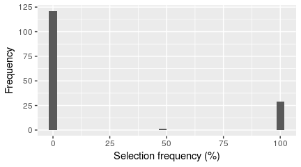

```r
# plot histogram showing solution frequency
ggplot(data = actions, aes(sel_freq)) +
geom_histogram(bins = 30) +
xlab("Selection frequency (%)") +
ylab("Frequency")
```

Although calculating selection frequency might seem appealing, it suffers from an assumption that is unrealistic for most real-world problems. Specifically, it assumes that our portfolio of solutions is a representative sample of the near-optimal solutions to the problem. And we do not currently have any method to verify this, except by enumerating all possible solutions—which is not feasible for reasonably sized problems. So now we shall examine a superior metric termed the “replacement cost” (Moilanen *et al.* 2009). Given a set of priority actions and a project prioritization problem, the replacement cost can be calculated for a given priority action by re-solving the problem with the priority action locked out, and calculating the difference between the objective value based on the priority actions and the new objective value with the priority action locked out. So let’s calculate the replacement cost for the priority actions in object `s2` using the problem `p2`.

```r
# print p2 to remind ourselves about the problem
print(p2)
```

```
# Project Prioritization Problem
#   actions          action_1, action_2, action_3, ... (151 actions)
#   projects         project_1, project_2, project_3, ... (101 projects)
#   features         F1, F2, F3, ... (50 features)
#   action costs:    min: 0, max: 111.90657
#   project success: min: 0.70358, max: 1
#   objective:       Maximum richness objective [budget (3000)]
#   targets:         none
#   weights:         min: 3e-05, max: 0.156
#   decisions        Binary decision
#   constraints:     <none>
#   solver:          default
```

```r
# print s2 to remind ourselves about the solution
print(s2)
```

```
# # A tibble: 1 x 205
#   solution status   obj  cost action_1 action_2 action_3 action_4 action_5
#      <int> <chr>  <dbl> <dbl>    <dbl>    <dbl>    <dbl>    <dbl>    <dbl>
# 1        1 OPTIM<80>  1.27 2990.        0        0        0        0        0
# # <80> with 196 more variables: action_6 <dbl>, action_7 <dbl>,
# #   action_8 <dbl>, action_9 <dbl>, action_10 <dbl>, action_11 <dbl>,
# #   action_12 <dbl>, action_13 <dbl>, action_14 <dbl>, action_15 <dbl>,
# #   action_16 <dbl>, action_17 <dbl>, action_18 <dbl>, action_19 <dbl>,
# #   action_20 <dbl>, action_21 <dbl>, action_22 <dbl>, action_23 <dbl>,
# #   action_24 <dbl>, action_25 <dbl>, action_26 <dbl>, action_27 <dbl>,
# #   action_28 <dbl>, action_29 <dbl>, action_30 <dbl>, action_31 <dbl>,
# #   action_32 <dbl>, action_33 <dbl>, action_34 <dbl>, action_35 <dbl>,
# #   action_36 <dbl>, action_37 <dbl>, action_38 <dbl>, action_39 <dbl>,
# #   action_40 <dbl>, action_41 <dbl>, action_42 <dbl>, action_43 <dbl>,
# #   action_44 <dbl>, action_45 <dbl>, action_46 <dbl>, action_47 <dbl>,
# #   action_48 <dbl>, action_49 <dbl>, action_50 <dbl>, action_51 <dbl>,
# #   action_52 <dbl>, action_53 <dbl>, action_54 <dbl>, action_55 <dbl>,
# #   action_56 <dbl>, action_57 <dbl>, action_58 <dbl>, action_59 <dbl>,
# #   action_60 <dbl>, action_61 <dbl>, action_62 <dbl>, action_63 <dbl>,
# #   action_64 <dbl>, action_65 <dbl>, action_66 <dbl>, action_67 <dbl>,
# #   action_68 <dbl>, action_69 <dbl>, action_70 <dbl>, action_71 <dbl>,
# #   action_72 <dbl>, action_73 <dbl>, action_74 <dbl>, action_75 <dbl>,
# #   action_76 <dbl>, action_77 <dbl>, action_78 <dbl>, action_79 <dbl>,
# #   action_80 <dbl>, action_81 <dbl>, action_82 <dbl>, action_83 <dbl>,
# #   action_84 <dbl>, action_85 <dbl>, action_86 <dbl>, action_87 <dbl>,
# #   action_88 <dbl>, action_89 <dbl>, action_90 <dbl>, action_91 <dbl>,
# #   action_92 <dbl>, action_93 <dbl>, action_94 <dbl>, action_95 <dbl>,
# #   action_96 <dbl>, action_97 <dbl>, action_98 <dbl>, action_99 <dbl>,
# #   action_100 <dbl>, action_101 <dbl>, action_102 <dbl>,
# #   action_103 <dbl>, action_104 <dbl>, action_105 <dbl>, <80>
```

```r
# calculate replacement costs for each priority action selected in s2
r2 <- replacement_costs(p2, s2)

# print output
print(r2)
```

```
# # A tibble: 151 x 4
#    name       cost   obj rep_cost
#    <chr>     <dbl> <dbl>    <dbl>
#  1 action_1     NA    NA       NA
#  2 action_2     NA    NA       NA
#  3 action_3     NA    NA       NA
#  4 action_4     NA    NA       NA
#  5 action_5     NA    NA       NA
#  6 action_6     NA    NA       NA
#  7 action_7     NA    NA       NA
#  8 action_8     NA    NA       NA
#  9 action_9     NA    NA       NA
# 10 action_10    NA    NA       NA
# # <80> with 141 more rows
```

```r
# add replacement costs to action table
actions$rep_cost <- r2$rep_cost

# print actions, ordered by replacement cost
print(actions[order(actions$rep_cost, decreasing = TRUE), ])
```

```
# # A tibble: 151 x 6
#    name        cost locked_in locked_out sel_freq rep_cost
#    <chr>      <dbl> <lgl>     <lgl>         <dbl>    <dbl>
#  1 action_23  105.  FALSE     FALSE           100  0.0373
#  2 action_34   98.6 FALSE     FALSE           100  0.0373
#  3 action_61  108.  FALSE     FALSE           100  0.0373
#  4 action_68   94.1 FALSE     FALSE           100  0.0373
#  5 action_113  97.8 FALSE     FALSE           100  0.0373
#  6 action_141 105.  FALSE     FALSE           100  0.0373
#  7 action_31   90.4 FALSE     FALSE           100  0.0119
#  8 action_49   94.6 FALSE     FALSE           100  0.0119
#  9 action_103 103.  FALSE     FALSE           100  0.00835
# 10 action_149  99.0 FALSE     FALSE           100  0.00835
# # <80> with 141 more rows
```

```r
# test correlation between selection frequencies and replacement costs
cor.test(x = actions$sel_freq, y = actions$rep_cost, method = "pearson")
```

```
#
#     Pearson's product-moment correlation
#
# data:  actions$sel_freq and actions$rep_cost
# t = 0.96095, df = 28, p-value = 0.3448
# alternative hypothesis: true correlation is not equal to 0
# 95 percent confidence interval:
#  -0.1940823  0.5063542
# sample estimates:
#       cor
# 0.1786806
```

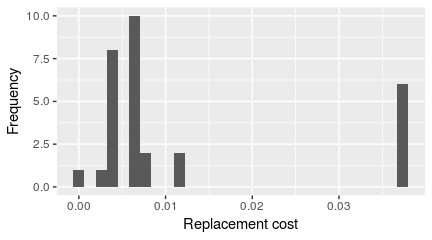

```r
# plot histogram of replacement costs,
ggplot(data = actions, aes(rep_cost)) +
geom_histogram(bins = 30, na.rm = TRUE) +
xlab("Replacement cost") +
ylab("Frequency")
```

## Citation

Please use the following citation to cite the *ppr R* package in publications:

Hanson JO, Schuster R, Strimas-Mackey M, Bennett J, (2019). ppr: Project Prioritization. R package version 0.0.0.1. Available at https://github.com/prioritizr/ppr.

## References

Ball, I.R., Possingham, H.P. & Watts, M. (2009). Marxan and relatives: Software for spatial conservation prioritisation. *Spatial conservation prioritisation: Quantitative methods and computational tools*, pp. 185–195. Oxford University Press Oxford.

Bennett, J.R., Elliott, G., Mellish, B., Joseph, L.N., Tulloch, A.I., Probert, W.J., Di Fonzo, M.M., Monks, J.M., Possingham, H.P. & Maloney, R. (2014). Balancing phylogenetic diversity and species numbers in conservation prioritizat, using a case study of threatened species in New Zealand. *Biological Conservation*, *174*, 47–54.

Beyer, H.L., Dujardin, Y., Watts, M.E. & Possingham, H.P. (2016). Solving conservation planning problems with integer linear programming. *Ecological Modelling*, *328*, 14–22.

Carwardine, J., Martin, T.G., Firn, J., Reyes, R.P., Nicol, S., Reeson, A., Grantham, H.S., Stratford, D., Kehoe, L. & Chadès, I. (2018). Priority Threat Management for biodiversity conservation: A handbook. *Journal of Applied Ecology*, *In press*, 10.1111/1365–2664.13268.

Gerber, L.R., Runge, M.C., Maloney, R.F., Iacona, G.D., Drew, C.A., Avery-Gomm, S., Brazill-Boast, J., Crouse, D., Epanchin-Niell, R.S., Hall, S.B. & others. (2018). Endangered species recovery: A resource allocation problem. *Science*, *362*, 284–286.

Joseph, L.N., Maloney, R.F. & Possingham, H.P. (2009). Optimal allocation of resources among threatened species: A project prioritization protocol. *Conservation Biology*, *23*, 328–338.

Kirkpatrick, S., Gelatt, C.D. & Vecchi, M.P. (1983). Optimization by simulated annealing. *Science*, *220*, 671–680.

Moilanen, A., Arponen, A., Stokland, J.N. & Cabeza, M. (2009). Assessing replacement cost of conservation areas: How does habitat loss influence priorities? *Biological Conservation*, *142*, 575–585.

Rodrigues, A.S. & Gaston, K.J. (2002). Optimisation in reserve selection procedures—why not? *Biological Conservation*, *107*, 123–129.

Underhill, L. (1994). Optimal and suboptimal reserve selection algorithms. *Biological Conservation*, *70*, 85–87.